# Week 4 - TSLA in January

Bill Foote

2021-01-29

## Tesla example

The question is:

> I see volume of trading rise. What will the stock price do?

The question gives rise to hypotheses. The data includes volume and price.

```r
tsla <- read_csv("tsla.csv")
d <- tsla[ , 2:4] # date not needed (yet!)
d$P <- standardize( d$price ) # first steps in regularizing
d$V <- standardize( d$volume )
precis( d )
```

```
##                 mean           sd          5.5%        94.5%
## price   1.724924e+02 1.136027e+02  5.109080e+01 4.111614e+02
## volume  6.979158e+07 4.089691e+07  2.255094e+07 1.422241e+08
## month   6.537549e+00 3.437014e+00  1.000000e+00 1.200000e+01
## P       7.269126e-17 1.000000e+00 -1.068650e+00 2.100910e+00
## V      -5.219737e-17 1.000000e+00 -1.155115e+00 1.771099e+00
##                                                                                       histogram
## price          ▁▇▅▅▁▂▁▁▂▁
## volume                                 ▇▇▂▁▁▁▁
## month  ▇▃▃▃▃▃▃▃▃▃▃
## P                      ▂▇▅▂▁▂▁▂▁
## V                              ▂▇▇▁▁▁▁▁
```

### A simple model emerges

The simplest geocentric (approximating model relative to our frame of reference, **us** ) model is:

$$\begin{align}
P &\sim Normal(\mu, \sigma) \\
\mu &= \alpha + \beta V \\
\alpha &\sim Normal(0, 0.5) \\
\beta &\sim Normal(0, 0.25) \\
\sigma &\sim Exponential(1)
\end{align}$$
We translate this math into R thusly.

```r
m1 <- quap(
  alist(
    P ~ dnorm(mu, sigma),
    mu <- a + b*V,
    a ~ dnorm( 0, 0.5 ),
    b ~ dnorm( 0, 0.25 ),
    sigma ~ dexp(1)
  ), data = d )
precis( m1 )
```

```
##               mean         sd        5.5%      94.5%
## a     4.704438e-07 0.05977983 -0.09553924 0.09554018
## b     2.602781e-01 0.05866125  0.16652613 0.35403016
## sigma 9.577261e-01 0.04246551  0.88985805 1.02559423
```

A MCMC version here.

```r
dmcmc <- list(
  P = d$P,
  V = d$V
)
m1_mcmc <- ulam(
  alist(
    P ~ dnorm(mu, sigma),
    mu <- a + b*V,
    a ~ dnorm( 0, 0.5 ),
    b ~ dnorm( 0, 0.25 ),
    sigma ~ dexp(1)
  ), data = d, chains = 1 )
precis( m1_mcmc )
```

```
##               mean         sd       5.5%      94.5%    n_eff     Rhat4
## a     -0.005956062 0.06256008 -0.1097892 0.09279471 430.3890 0.9982988
## b      0.262643171 0.06217385  0.1590297 0.35888819 478.4067 0.9980024
## sigma  0.963393155 0.04624583  0.8959437 1.03660331 460.4502 0.9980491
```

```r
logVbar <- mean( log(d$volume) )
m2 <- quap(
  alist(
    price ~ dnorm(mu_logP, sigma_logP),
    mu_logP <- a + b*( log(volume) - logVbar),
    a ~ dnorm( 1, 0.5 ),
    b ~ dnorm( 1, 0.25 ),
    sigma_logP ~ dexp(1)
  ), data = d )
precis( m2 )
```

```
##                  mean        sd        5.5%      94.5%
## a            1.420329 0.5001015   0.6210698   2.219587
## b            1.014478 0.2499749   0.6149695   1.413986
## sigma_logP 160.451448 5.1136315 152.2788769 168.624019
```

```r
compare( m1, m2, func = WAIC)
```

```
##         WAIC       SE    dWAIC      dSE    pWAIC weight
## m1  703.1979 22.86221    0.000       NA 3.125396      1
## m2 3449.9542 33.45230 2746.756 17.87245 1.237469      0
```

It appears that `m1` has a lower level of probable incompatibility of the model with the data than does `m2`. It does so with less variability and a higher penalty to parameters across the samples in the predictive simulation. It is simply tighter.

### The January Effect

One more model rears its head. This model indexes months of the year to test for a [January effect](https://www.investopedia.com/terms/j/januaryeffect.asp#:~:text=The%20January%20effect%20is%20a%20perceived%20seasonal%20increase,to%20offset%20realized%20capital%20gains%2C%20prompt%20a%20sell-off.). This effect seems to explain higher stock prices in January as investors buy back stocks sold off in December. What is the intervening event? Tax season begins in December as investors harvest tax-losses to balance increases in capital gains on the appreciation of their stocks in the past year or simply pile their year-end cash bonuses into the stock market.

We code the January days with this rendering in R.

```r
d$mid <- ifelse( d$month==1 , 1L , 2L )
```

where `mid` is the month ID for January.

```r
m3 <- quap(
  alist(
    P ~ dnorm(mu, sigma),
    mu <- a[mid] + b[mid]*V,
    a[mid] ~ dnorm( 0, 0.5 ),
    b[mid] ~ dnorm( 0, 0.25 ),
    sigma ~ dexp(1)
  ), data = d )
precis( m3, digits = 2, depth = 2 )
```

```
##              mean         sd        5.5%      94.5%
## a[1]  -0.49122037 0.21077434 -0.82807848 -0.1543623
## a[2]   0.07157715 0.06043133 -0.02500378  0.1681581
## b[1]  -0.02465844 0.16887339 -0.29455073  0.2452338
## b[2]   0.32393900 0.05970076  0.22852566  0.4193523
## sigma  0.92564317 0.04107718  0.85999389  0.9912924
```

Let’s expand the tails using a thick-tailed Student’s-t distribution with degrees of freedom $\nu=2$.

```r
m4 <- quap(
  alist(
    P ~ dstudent(2, mu, sigma),
    mu <- a[mid] + b[mid]*V,
    a[mid] ~ dnorm( 0, 0.5 ),
    b[mid] ~ dnorm( 0, 0.25 ),
    sigma ~ dexp(1)
  ), data = d )
precis( m3, digits = 2, depth = 2 )
```

```
##              mean         sd        5.5%      94.5%
## a[1]  -0.49122037 0.21077434 -0.82807848 -0.1543623
## a[2]   0.07157715 0.06043133 -0.02500378  0.1681581
## b[1]  -0.02465844 0.16887339 -0.29455073  0.2452338
## b[2]   0.32393900 0.05970076  0.22852566  0.4193523
## sigma  0.92564317 0.04107718  0.85999389  0.9912924
```

Perhaps a model bake-off will perk us up.

```r
compare( m1, m3 , m4)
```

```
##        WAIC       SE     dWAIC       dSE    pWAIC       weight
## m3 688.1394 23.09334  0.000000        NA 3.851516 0.9907274744
## m4 697.5824 32.98238  9.442951 15.101258 5.973376 0.0088194891
## m1 703.5199 22.88571 15.380444  5.186613 3.227124 0.0004530365
```

Including the January effect definitely improves the deviance over the first and definitely the second. This picture will capture a bit of this

[figure not shown]

```r
just_volume <- extract.samples( m1 )$sigma
with_january <- extract.samples( m3 )$sigma
with_tails_january <- extract.samples( m4 )$sigma

tibble( sim =1:10000, just_volume, with_january, with_tails_january ) %>%
  pivot_longer( -sim, names_to = "model", values_to = "sigma") %>%
  mutate(january_present = if_else(model == "with_january", FALSE, TRUE)) %>%
  ggplot(aes(sigma, model, fill = january_present)) +
  geom_density_ridges() +
  scale_fill_viridis_d() +
  theme(legend.position = "bottom") +
  labs(title = "Predicted variation across traded volume",
       subtitle = "Presence of January explains some of the variation across volume.")
```

The ridges diagram depicts the range and location of the regression `sigma`s. It is clear that a January model with thickened tails will provide more predictive ability than not. Even though the WAIC of the January model with Gaussian tails (not so thick or inclusive of potential outliers) is best in class, this plot would seem to lean toward a robust sampling of stock prices conditional on trading volumes controlled by a month of January effect.

We can further view the impact of the sensitivity of January on prices with this plot.

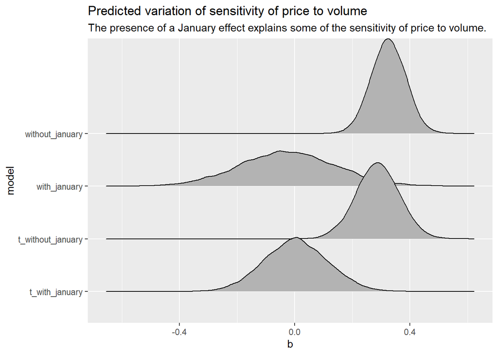

```r
with_january <- extract.samples( m3 )$b[ ,1 ]
without_january <- extract.samples( m3 )$b[ ,2 ]
t_with_january <- extract.samples( m4 )$b[,1 ]
t_without_january <- extract.samples( m4 )$b[ ,2 ]

plot_extract <- tibble( sim =1:10000, with_january, without_january, t_with_january, t_without_january ) %>%
  pivot_longer( -sim, names_to = "model", values_to = "b")
plot_extract %>%
  ggplot( aes( b, model) ) +
    geom_density_ridges() +
    scale_fill_viridis_d() +
    theme(legend.position = "bottom") +
    labs(title = "Predicted variation of sensitivity of price to volume",
         subtitle = "The presence of a January effect explains some of the sensitivity of price to volume.")
```

```r
# %>%
#  mutate( january_present = if_else( (model != "t_with_january") | (model != "with_January"), FALSE, TRUE ) )
```

```r
dmcmc <- list(
  P = d$P,
  V = d$V,
  d$mid <- ifelse( d$month==1 , 1L , 2L )
)
m4_mcmc <- ulam(
  alist(
    P ~ dstudent(2, mu, sigma),
    mu <- a[mid] + b[mid]*V,
    a[mid] ~ dnorm( 0, 0.5 ),
    b[mid] ~ dnorm( 0, 0.25 ),
    sigma ~ dexp(1)
  ), data = d )
precis( m4_mcmc, digits = 2, depth = 2 )
```

```
##               mean         sd       5.5%      94.5%    n_eff     Rhat4
## a[1]  -0.559999671 0.13934678 -0.7549267 -0.3314398 277.1712 1.0010888
## a[2]  -0.229906217 0.06018265 -0.3236998 -0.1299059 439.4754 0.9980086
## b[1]  -0.001645844 0.11873753 -0.1974700  0.1844566 276.2023 0.9980537
## b[2]   0.290405762 0.07446942  0.1692837  0.4073482 450.8348 0.9984686
## sigma  0.587090133 0.04249901  0.5216776  0.6574782 440.3798 0.9981017
```